# Iris Flower CaseStudy

#### 2.2.2 Distribution Analysis

```r
meanMedian<-iris %>%
  group_by(Species) %>%
  summarise(Spl.len.mean=mean(Sepal.Length),spl.len.median=median(Sepal.Length),
            Spl.Width.mean=mean(Sepal.Width),Spl.Width.median=median(Sepal.Width),
            ptl.len.mean=mean(Petal.Length),ptl.len.median=median(Petal.Length),
            ptl.width.mean=mean(Petal.Width),ptl.Width.median=median(Petal.Width))
```

```r
kable(meanMedian)  %>% kable_styling(bootstrap_options = c("striped", "hover", "responsive")) %>% scroll_box(width = "100%", height = "250px")
```

| Species | Spl.len.mean | spl.len.median | Spl.Width.mean | Spl.Width.median | ptl.len.mean | ptl.len.median | ptl.width.mean | ptl.Width.median |
| --- | --- | --- | --- | --- | --- | --- | --- | --- |
| setosa | 5.006 | 5.0 | 3.428 | 3.4 | 1.462 | 1.50 | 0.246 | 0.2 |
| versicolor | 5.936 | 5.9 | 2.770 | 2.8 | 4.260 | 4.35 | 1.326 | 1.3 |
| virginica | 6.588 | 6.5 | 2.974 | 3.0 | 5.552 | 5.55 | 2.026 | 2.0 |

**Observation**

More clarity will come lokking at the histogram distributions

#### 2.2.3 Histogram: All species

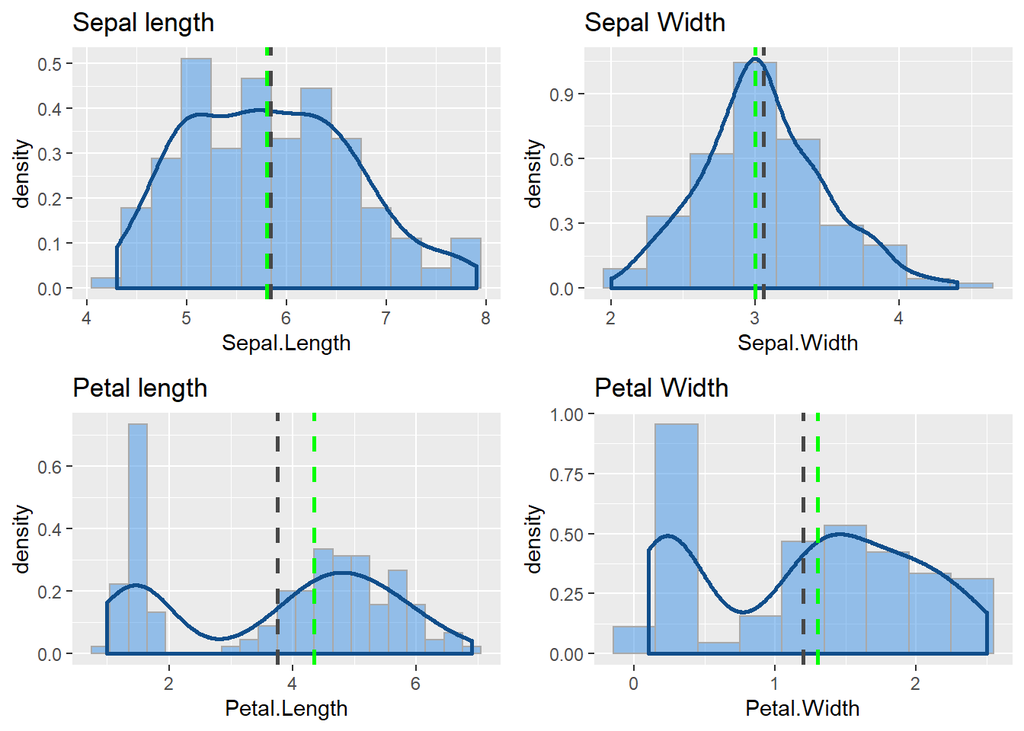

```r
  sl<-ggplot(iris, aes(Sepal.Length))+
  geom_histogram(alpha=0.5, binwidth =.3,position="identity", aes(y = ..density..), color="darkgray",fill='#3990E5' ) +
  geom_density(alpha=0.7,color="dodgerblue4",size=1) +
  geom_vline(aes(xintercept=mean(Sepal.Length))
             , color="grey28", linetype="dashed", size=1) +
  geom_vline(aes(xintercept=median(Sepal.Length))
             , color="green", linetype="dashed", size=1) +
  labs(title = "Sepal length")

 sw<-ggplot(iris, aes(Sepal.Width))+
  geom_histogram(alpha=0.5, binwidth =.3,position="identity", aes(y = ..density..), color="darkgray",fill='#3990E5' ) +
  geom_density(alpha=0.7,color="dodgerblue4",size=1) +
  geom_vline(aes(xintercept=mean(Sepal.Width))
             , color="grey28", linetype="dashed", size=1) +
  geom_vline(aes(xintercept=median(Sepal.Width))
             , color="green", linetype="dashed", size=1) +
  labs(title = "Sepal Width")

  pl<-ggplot(iris, aes(Petal.Length))+
  geom_histogram(alpha=0.5, binwidth =.3,position="identity", aes(y = ..density..), color="darkgray",fill='#3990E5' ) +
  geom_density(alpha=0.7,color="dodgerblue4",size=1) +
  geom_vline(aes(xintercept=mean(Petal.Length))
             , color="grey28", linetype="dashed", size=1) +
  geom_vline(aes(xintercept=median(Petal.Length))
             , color="green", linetype="dashed", size=1) +
  labs(title = "Petal length")

  pw<- ggplot(iris, aes(Petal.Width))+
  geom_histogram(alpha=0.5, binwidth =.3,position="identity", aes(y = ..density..), color="darkgray",fill='#3990E5' ) +
  geom_density(alpha=0.7,color="dodgerblue4",size=1) +
  geom_vline(aes(xintercept=mean(Petal.Width))
             , color="grey28", linetype="dashed", size=1) +
  geom_vline(aes(xintercept=median(Petal.Width))
             , color="green", linetype="dashed", size=1) +
  labs(title = "Petal Width")

  grid.arrange(sl,sw,pl,pw,ncol=2,nrow=2)
```

**Observation** All 3 flowers when taken in unison Petal length and Petal width form a bi modal density plot. Also, notice that mean and median values for Petal width and Petal Length has significant difference.

We can find out more insights by looking at each flower specie separately.

#### 2.2.4 Histogram: Setosa

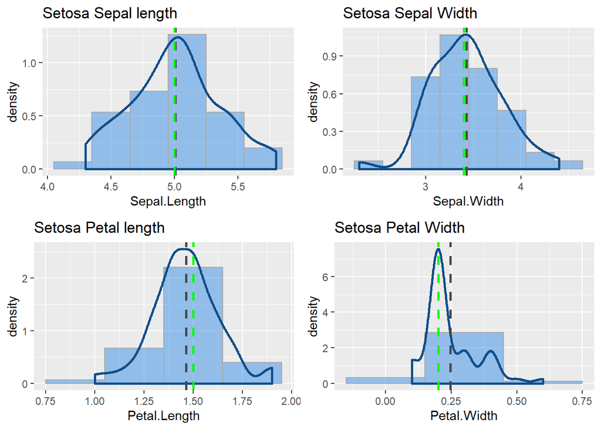

```r
iris_s<-subset(iris,Species=="setosa")

sl_Set<-ggplot(iris_s, aes(Sepal.Length))+
  geom_histogram(alpha=0.5, binwidth =.3,position="identity", aes(y = ..density..), color="darkgray",fill='#3990E5' ) +
  geom_density(alpha=0.7,color="dodgerblue4",size=1) +
  geom_vline(aes(xintercept=mean(Sepal.Length))
             , color="grey28", linetype="dashed", size=1) +
  geom_vline(aes(xintercept=median(Sepal.Length))
             , color="green", linetype="dashed", size=1) +
  labs(title = "Setosa Sepal length")

 sw_Set<-ggplot(iris_s, aes(Sepal.Width))+
  geom_histogram(alpha=0.5, binwidth =.3,position="identity", aes(y = ..density..), color="darkgray",fill='#3990E5' ) +
  geom_density(alpha=0.7,color="dodgerblue4",size=1) +
  geom_vline(aes(xintercept=mean(Sepal.Width))
             , color="grey28", linetype="dashed", size=1) +
  geom_vline(aes(xintercept=median(Sepal.Width))
             , color="green", linetype="dashed", size=1) +
  labs(title = "Setosa Sepal Width")

  pl_Set<-ggplot(iris_s, aes(Petal.Length))+
  geom_histogram(alpha=0.5, binwidth =.3,position="identity", aes(y = ..density..), color="darkgray",fill='#3990E5' ) +
  geom_density(alpha=0.7,color="dodgerblue4",size=1) +
  geom_vline(aes(xintercept=mean(Petal.Length))
             , color="grey28", linetype="dashed", size=1) +
  geom_vline(aes(xintercept=median(Petal.Length))
             , color="green", linetype="dashed", size=1) +
  labs(title = "Setosa Petal length")

  pw_Set<- ggplot(iris_s, aes(Petal.Width))+
  geom_histogram(alpha=0.5, binwidth =.3,position="identity", aes(y = ..density..), color="darkgray",fill='#3990E5' ) +
  geom_density(alpha=0.7,color="dodgerblue4",size=1) +
  geom_vline(aes(xintercept=mean(Petal.Width))
             , color="grey28", linetype="dashed", size=1) +
  geom_vline(aes(xintercept=median(Petal.Width))
             , color="green", linetype="dashed", size=1) +
  labs(title = "Setosa Petal Width")

  grid.arrange(sl_Set,sw_Set,pl_Set,pw_Set,ncol=2,nrow=2)
```

**Observation**

All but Petal width for Setosa seems to have a rough density plot, The plot also seems right skewed.

#### 2.2.5 Histogram: Versicolor

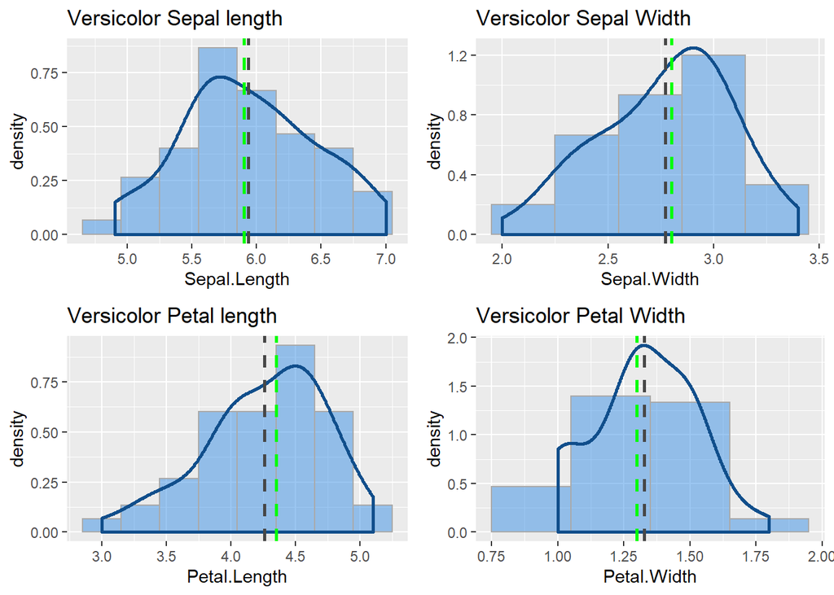

```r
iris_ve<-subset(iris,Species=="versicolor")

sl_ve<-ggplot(iris_ve, aes(Sepal.Length))+
  geom_histogram(alpha=0.5, binwidth =.3,position="identity", aes(y = ..density..), color="darkgray",fill='#3990E5' ) +
  geom_density(alpha=0.7,color="dodgerblue4",size=1) +
  geom_vline(aes(xintercept=mean(Sepal.Length))
             , color="grey28", linetype="dashed", size=1) +
  geom_vline(aes(xintercept=median(Sepal.Length))
             , color="green", linetype="dashed", size=1) +
  labs(title = "Versicolor Sepal length")

 sw_ve<-ggplot(iris_ve, aes(Sepal.Width))+
  geom_histogram(alpha=0.5, binwidth =.3,position="identity", aes(y = ..density..), color="darkgray",fill='#3990E5' ) +
  geom_density(alpha=0.7,color="dodgerblue4",size=1) +
  geom_vline(aes(xintercept=mean(Sepal.Width))
             , color="grey28", linetype="dashed", size=1) +
  geom_vline(aes(xintercept=median(Sepal.Width))
             , color="green", linetype="dashed", size=1) +
  labs(title = "Versicolor Sepal Width")

  pl_ve<-ggplot(iris_ve, aes(Petal.Length))+
  geom_histogram(alpha=0.5, binwidth =.3,position="identity", aes(y = ..density..), color="darkgray",fill='#3990E5' ) +
  geom_density(alpha=0.7,color="dodgerblue4",size=1) +
  geom_vline(aes(xintercept=mean(Petal.Length))
             , color="grey28", linetype="dashed", size=1) +
  geom_vline(aes(xintercept=median(Petal.Length))
             , color="green", linetype="dashed", size=1) +
  labs(title = "Versicolor Petal length")

  pw_ve<- ggplot(iris_ve, aes(Petal.Width))+
  geom_histogram(alpha=0.5, binwidth =.3,position="identity", aes(y = ..density..), color="darkgray",fill='#3990E5' ) +
  geom_density(alpha=0.7,color="dodgerblue4",size=1) +
  geom_vline(aes(xintercept=mean(Petal.Width))
             , color="grey28", linetype="dashed", size=1) +
  geom_vline(aes(xintercept=median(Petal.Width))
             , color="green", linetype="dashed", size=1) +
  labs(title = "Versicolor Petal Width")

  grid.arrange(sl_ve,sw_ve,pl_ve,pw_ve,ncol=2,nrow=2)
```

**Observation**

As compared to Setosa Versicolor seems to have more skewed distributions, specially in categories of Petal length and Petal Width.

#### 2.2.6 Histogram: Virginica

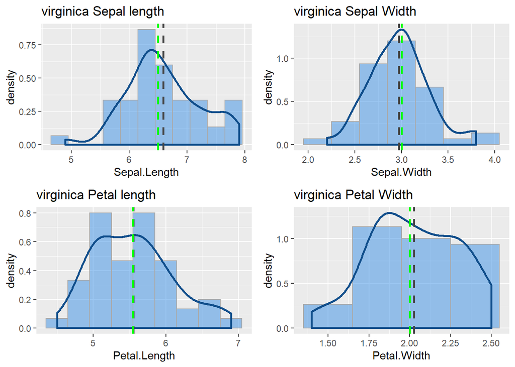

```r
iris_vi<-subset(iris,Species=="virginica")

sl_vi<-ggplot(iris_vi, aes(Sepal.Length))+
  geom_histogram(alpha=0.5, binwidth =.3,position="identity", aes(y = ..density..), color="darkgray",fill='#3990E5' ) +
  geom_density(alpha=0.7,color="dodgerblue4",size=1) +
  geom_vline(aes(xintercept=mean(Sepal.Length))
             , color="grey28", linetype="dashed", size=1) +
  geom_vline(aes(xintercept=median(Sepal.Length))
             , color="green", linetype="dashed", size=1) +
  labs(title = "virginica Sepal length")

 sw_vi<-ggplot(iris_vi, aes(Sepal.Width))+
  geom_histogram(alpha=0.5, binwidth =.3,position="identity", aes(y = ..density..), color="darkgray",fill='#3990E5' ) +
  geom_density(alpha=0.7,color="dodgerblue4",size=1) +
  geom_vline(aes(xintercept=mean(Sepal.Width))
             , color="grey28", linetype="dashed", size=1) +
  geom_vline(aes(xintercept=median(Sepal.Width))
             , color="green", linetype="dashed", size=1) +
  labs(title = "virginica Sepal Width")

  pl_vi<-ggplot(iris_vi, aes(Petal.Length))+
  geom_histogram(alpha=0.5, binwidth =.3,position="identity", aes(y = ..density..), color="darkgray",fill='#3990E5' ) +
  geom_density(alpha=0.7,color="dodgerblue4",size=1) +
  geom_vline(aes(xintercept=mean(Petal.Length))
             , color="grey28", linetype="dashed", size=1) +
  geom_vline(aes(xintercept=median(Petal.Length))
             , color="green", linetype="dashed", size=1) +
  labs(title = "virginica Petal length")

  pw_vi<- ggplot(iris_vi, aes(Petal.Width))+
  geom_histogram(alpha=0.5, binwidth =.3,position="identity", aes(y = ..density..), color="darkgray",fill='#3990E5' ) +
  geom_density(alpha=0.7,color="dodgerblue4",size=1) +
  geom_vline(aes(xintercept=mean(Petal.Width))
             , color="grey28", linetype="dashed", size=1) +
  geom_vline(aes(xintercept=median(Petal.Width))
             , color="green", linetype="dashed", size=1) +
  labs(title = "virginica Petal Width")

  grid.arrange(sl_vi,sw_vi,pl_vi,pw_vi,ncol=2,nrow=2)
```

**Observation**

Similar to Versicolor, Virginica also seems to have skewed distributions, specially in the case of Petal Length and Prtal Width.

### 2.3 Detecting Outliers with Boxplot

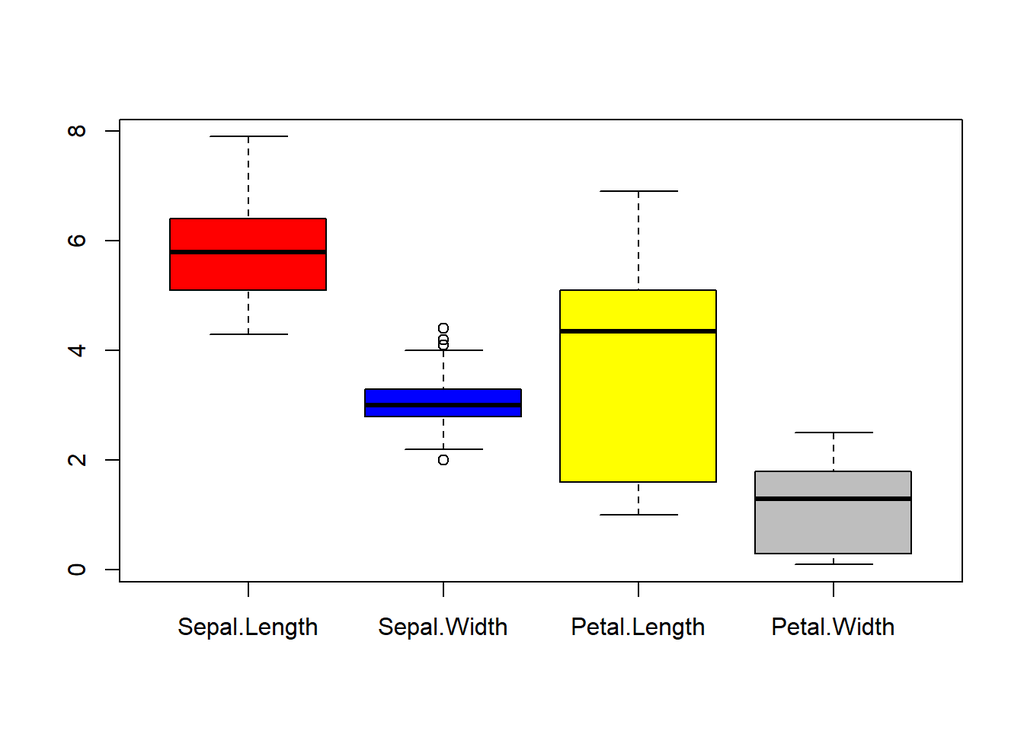

```r
###Checking for outliers
boxplot(iris[,1:4], col=c("red", "blue", "yellow", "grey"))
```

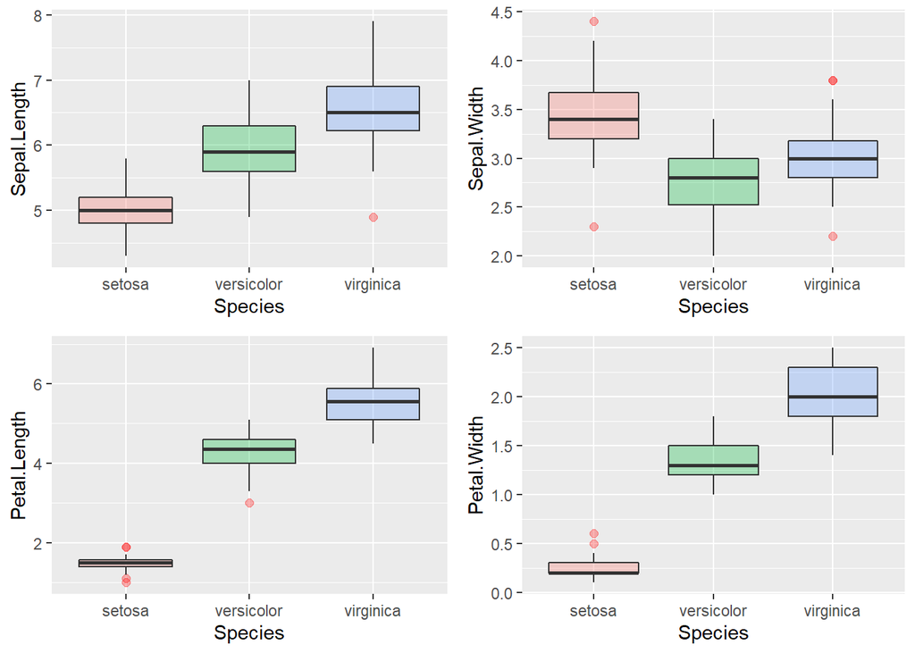

```r
slb<-ggplot(iris, aes(x=Species, y=Sepal.Length, fill=Species)) +
    geom_boxplot(
        alpha=0.3,
        outlier.colour="red",
        outlier.fill="red",
        outlier.size=2) +
    theme(legend.position="none")

swb<-ggplot(iris, aes(x=Species, y=Sepal.Width, fill=Species)) +
    geom_boxplot(
        alpha=0.3,
        outlier.colour="red",
        outlier.fill="red",
        outlier.size=2) +
    theme(legend.position="none")

plb<-ggplot(iris, aes(x=Species, y=Petal.Length, fill=Species)) +
    geom_boxplot(
        alpha=0.3,
        outlier.colour="red",
        outlier.fill="red",
        outlier.size=2) +
    theme(legend.position="none")

plw<-ggplot(iris, aes(x=Species, y=Petal.Width, fill=Species)) +
    geom_boxplot(
        alpha=0.3,
        outlier.colour="red",
        outlier.fill="red",
        outlier.size=2) +
    theme(legend.position="none")

grid.arrange(slb,swb,plb,plw,ncol=2,nrow=2)
```

**Scatter plot**

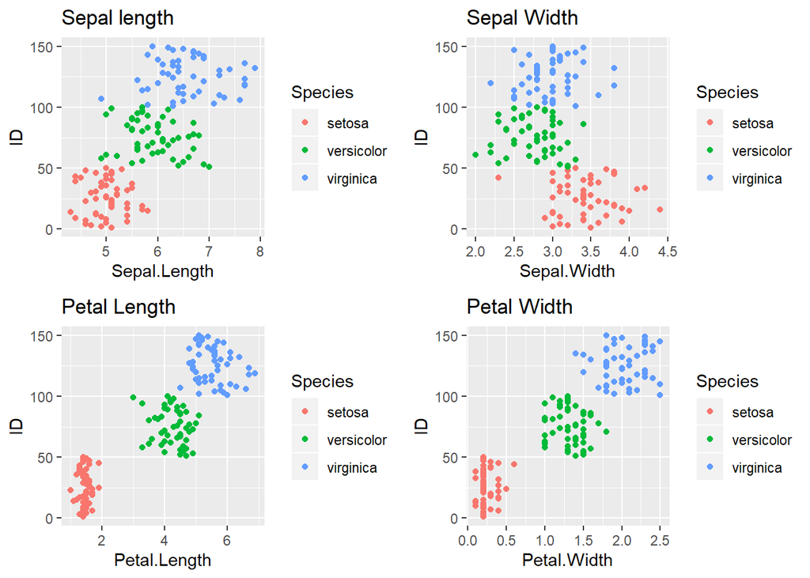

```r
iris1<-iris
iris1$ID <- seq.int(nrow(iris1))
sls<-ggplot(iris1, aes(x=Sepal.Length, y=ID,  color=Species)) + geom_point() +labs(title = "Sepal length")

sws<-ggplot(iris1, aes(x=Sepal.Width, y=ID,  color=Species)) + geom_point() +labs(title = "Sepal Width")

pls<-ggplot(iris1, aes(x=Petal.Length, y=ID,  color=Species)) + geom_point() +labs(title = "Petal Length")

pws<-ggplot(iris1, aes(x=Petal.Width, y=ID,  color=Species)) + geom_point() +labs(title = "Petal Width")

grid.arrange(sls,sws,pls,pws,ncol=2,nrow=2)
```

**Observation**

- Sepal Length: Have minor overlap in 3 species
- Sepal Width : Have considerably higher overlap in 3 species
- Petal Length: Have a clear distinction in 3 species
- Petal Width: Have a clear distinction in 3 species

Ranking based on scatter plot Petal Width > Petal Length > Sepal Length > Sepal Width

### 2.4 Correlation Analysis

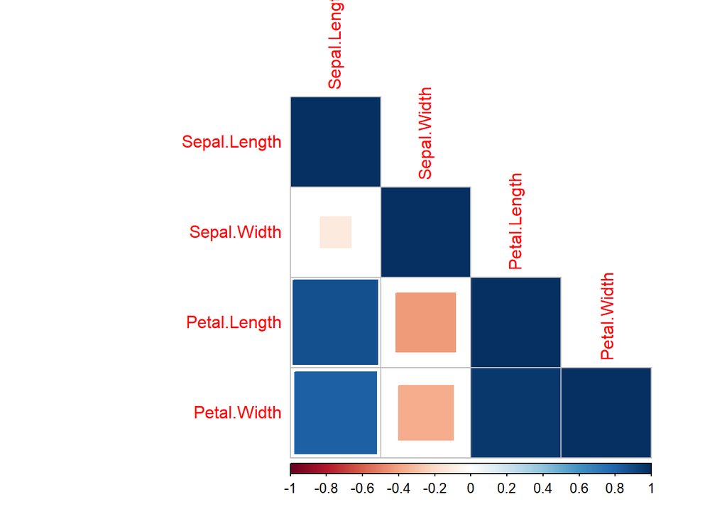

```r
library(corrplot)
C<-cor(iris[,c(1:4)])
c0<-corrplot(C,  method = "square",type="lower")
```

```r
??corrplot()
```

```
## starting httpd help server ...
```

```
##  done
```

**Observation**

- Strong Correlation in Sepal Length and Petal Length.
- Strong Correlation in Sepal Length and Petal width.

*Inference: Flowers with Longer sepal tend to have wider and longer Petals*

- Negative Correlation between Sepal width and Petal Length *Inference: As sepal width increases the petals tend to be shorter in length*
- Negative Correlation between Sepal width and Petal width *Inference: As sepal width increases the petals tend to be shorter in length as well as in width*
- Strong Correlation in Petal Length and Petal width. *Inference: As petal width increases petals tend to be wider*

### 2.5 Density Ridgeline plots

The density ridgeline plot is an alternative to the standard geom_density() function that can be useful for visualizing changes in distributions, of a continuous variable, over time or space. Ridgeline plots are partially overlapping line plots that create the impression of a mountain range.

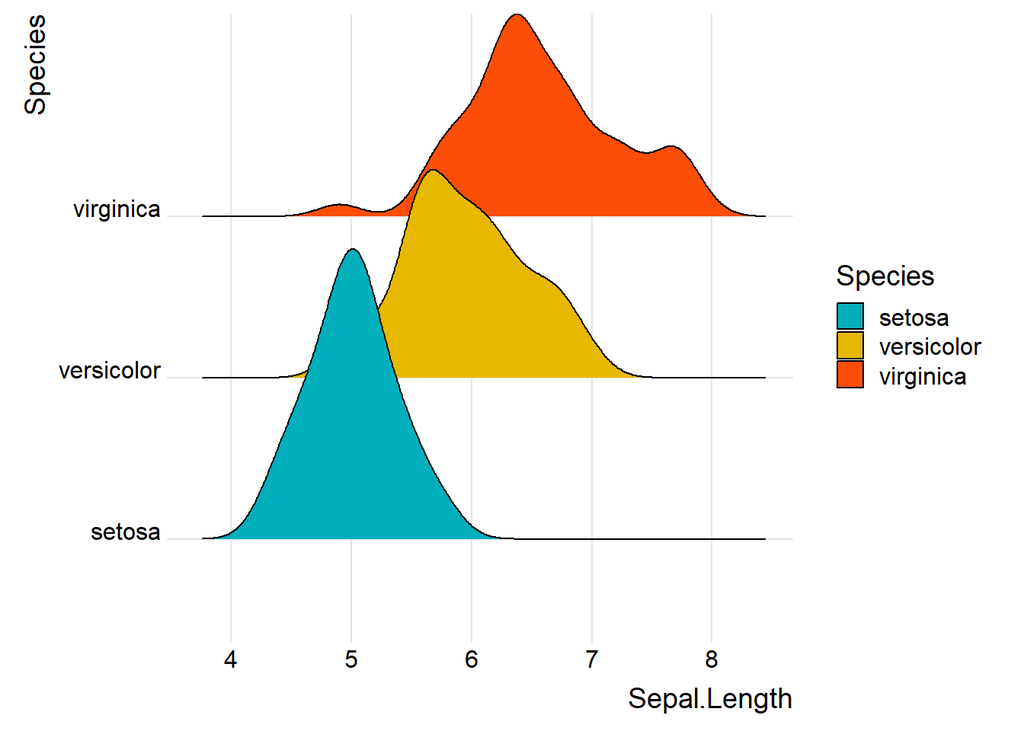

```r
theme_set(theme_ridges())

p1<-ggplot(iris, aes(x = Sepal.Length, y = Species)) +
  geom_density_ridges(aes(fill = Species)) +
  scale_fill_manual(values = c("#00AFBB", "#E7B800", "#FC4E07"))

p2<-ggplot(iris, aes(x = Sepal.Width, y = Species)) +
  geom_density_ridges(aes(fill = Species)) +
  scale_fill_manual(values = c("#00AFBB", "#E7B800", "#FC4E07"))


p3<-ggplot(iris, aes(x = Petal.Width, y = Species)) +
  geom_density_ridges(aes(fill = Species)) +
  scale_fill_manual(values = c("#00AFBB", "#E7B800", "#FC4E07"))


p4<-ggplot(iris, aes(x = Petal.Width, y = Species)) +
  geom_density_ridges(aes(fill = Species)) +
  scale_fill_manual(values = c("#00AFBB", "#E7B800", "#FC4E07"))
library(ggpubr)
p1
```

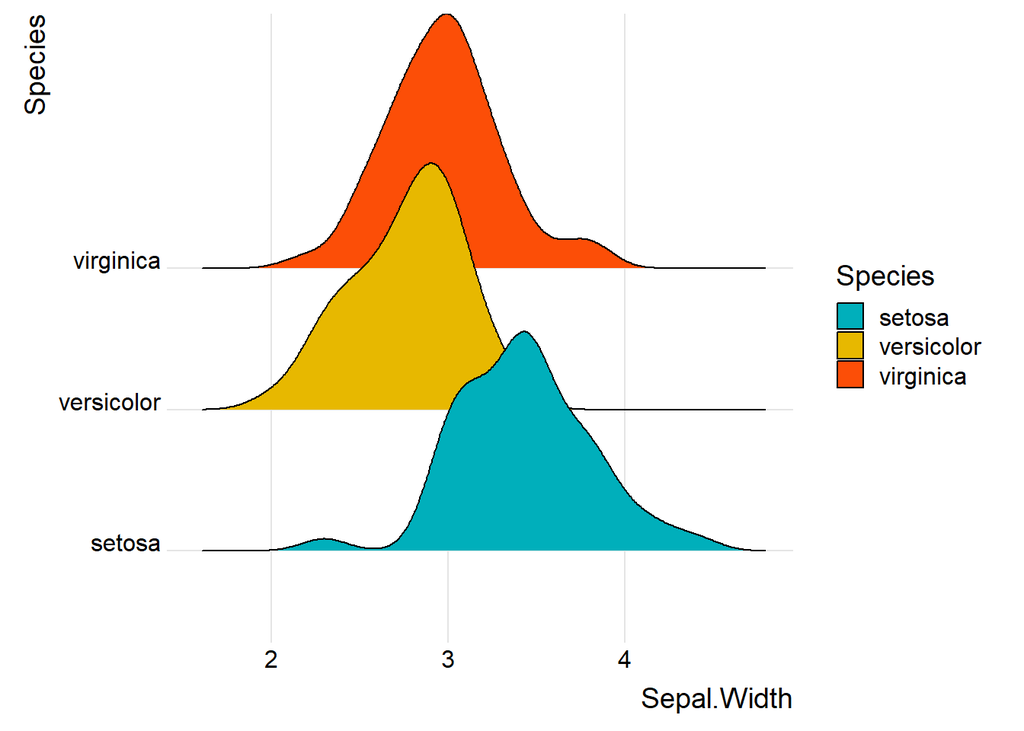

```r
p2
```

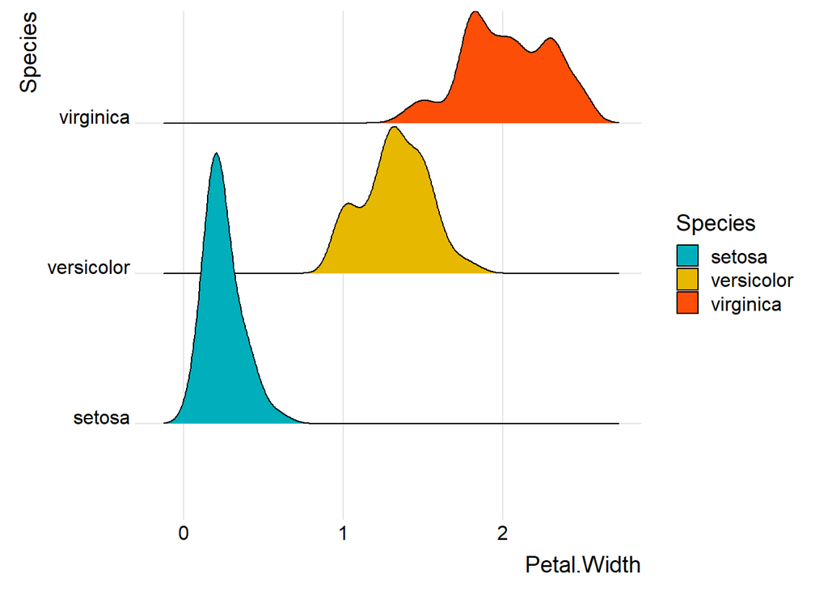

```r
p3
```

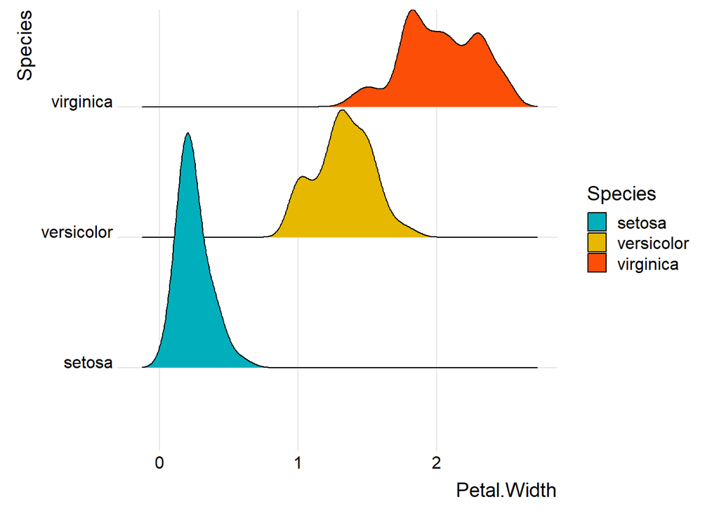

```r
p4
```

**Thankyou…!**